# Results (Iteration 1)

Eric Czech

13 February, 2016, 06:29

# Classification Results

## Models Considered

Models tried so far:

- ElasticNet (+ ridge/lasso)
- SVM (radial)
- PAM aka “Predictive Analysis for Microarrays” (basically shrunken centroids)
- kNN (also w/ PCA preprocessing)
- Partial Least Squares
- Random Forest

In the works:

- [SCRDA](https://web.stanford.edu/~hastie/Papers/RDA-6.pdf) - This looks promising
- RDA (a simpler version of the above)
- GBM / ExtraTrees

## Data Prep and Partitioning

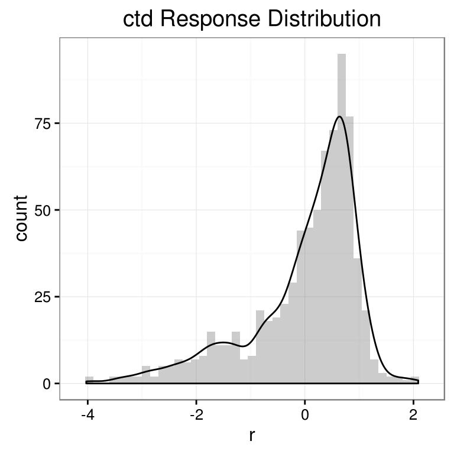

## CV Results (ROC)

ROC curves across models and folds on training data:

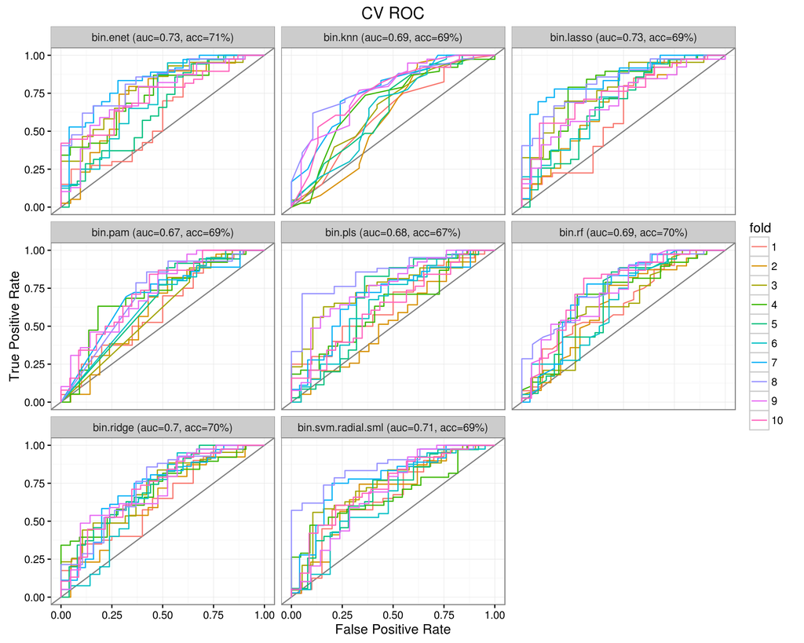

## CV ROC (combined)

ROC curves combined across folds (should resemble holdout ROC):

[interactive chart not shown]

## Holdout ROC

ROC curves by model on hold out data:

[interactive chart not shown]

## Accuracy Summary

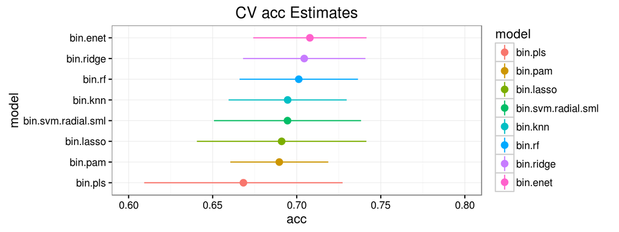

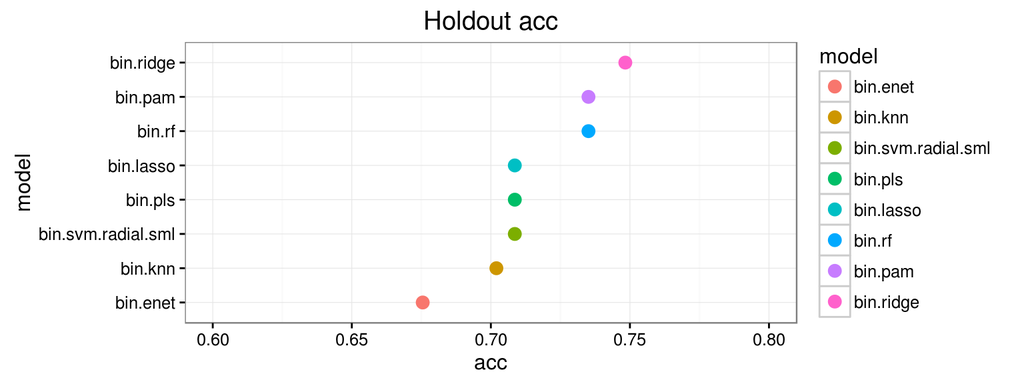

## Accuracy With Margins

Here is a look at how the accuracy changes when taking the probabilities of each positive class prediction and then adding a “margin” around them (centered on .5). This creates a third type of prediction for when the classifiers are less certain of which class to predict. The size of the margin around .5 is on the X axis and the error bars indicate the 25% and 75% percentile of the accuracy numbers in 10 fold CV:

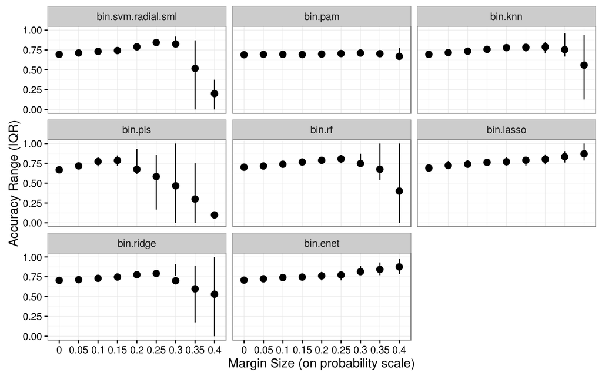

## AUC Summary

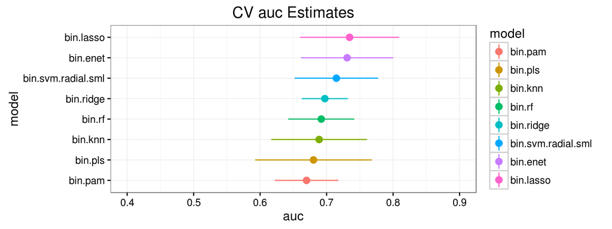

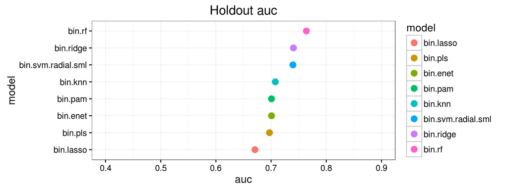